# Unified Analysis — LLM Phrasal Compositionality

### Joint freq × FTP surface at final layer — per model (bam)

```r
set.seed(964)
blm_bam_joint_indep_final_models = lapply(setNames(BLM_TAGS, BLM_TAGS), function(tag) {
  blm_cache_bam(paste0("bam_joint_indep_final_", blm_slug(tag)), function() {
    bam(logit ~ te(log_freq, log_ftp) + s(verb_up, bs = 're'),
        data = blm_indep_final_ftp %>% filter(model == tag), method = 'fREML', discrete = TRUE)
  })
})
blm_bam_joint_sub_final_models = lapply(setNames(BLM_TAGS, BLM_TAGS), function(tag) {
  blm_cache_bam(paste0("bam_joint_sub_final_", blm_slug(tag)), function() {
    bam(logit ~ te(log_freq, log_ftp) + s(verb_up, bs = 're'),
        data = blm_sub_final_ftp %>% filter(model == tag), method = 'fREML', discrete = TRUE)
  })
})
lapply(blm_bam_joint_indep_final_models, summary)
```

```
## $`opt-125m`
##
## Family: gaussian
## Link function: identity
##
## Formula:
## logit ~ te(log_freq, log_ftp) + s(verb_up, bs = "re")
##
## Parametric coefficients:
##             Estimate Std. Error t value Pr(>|t|)
## (Intercept)    8.814      0.043     205   <2e-16 ***
## ---
## Signif. codes:  0 '***' 0.001 '**' 0.01 '*' 0.05 '.' 0.1 ' ' 1
##
## Approximate significance of smooth terms:
##                         edf  Ref.df     F p-value
## te(log_freq,log_ftp)  14.43   14.63 13.05  <2e-16 ***
## s(verb_up)           940.90 1035.00 13.54  <2e-16 ***
## ---
## Signif. codes:  0 '***' 0.001 '**' 0.01 '*' 0.05 '.' 0.1 ' ' 1
##
## R-sq.(adj) =   0.41   Deviance explained = 43.8%
## fREML =  37840  Scale est. = 2.0488    n = 20541
##
## $`opt-350m`
##
## Family: gaussian
## Link function: identity
##
## Formula:
## logit ~ te(log_freq, log_ftp) + s(verb_up, bs = "re")
##
## Parametric coefficients:
##             Estimate Std. Error t value Pr(>|t|)
## (Intercept)  8.47398    0.04555     186   <2e-16 ***
## ---
## Signif. codes:  0 '***' 0.001 '**' 0.01 '*' 0.05 '.' 0.1 ' ' 1
##
## Approximate significance of smooth terms:
##                         edf Ref.df     F p-value
```

[output cut: 16 more lines]

```
## Parametric coefficients:
##             Estimate Std. Error t value Pr(>|t|)
## (Intercept)   8.7370     0.0608   143.7   <2e-16 ***
## ---
## Signif. codes:  0 '***' 0.001 '**' 0.01 '*' 0.05 '.' 0.1 ' ' 1
##
## Approximate significance of smooth terms:
##                         edf Ref.df     F p-value
## te(log_freq,log_ftp)  11.28   11.5 12.28  <2e-16 ***
## s(verb_up)           940.35 1035.0 12.69  <2e-16 ***
## ---
## Signif. codes:  0 '***' 0.001 '**' 0.01 '*' 0.05 '.' 0.1 ' ' 1
##
## R-sq.(adj) =  0.388   Deviance explained = 41.7%
## fREML =  45243  Scale est. = 4.2236    n = 20541
```

```r
lapply(blm_bam_joint_sub_final_models, summary)
```

```
## $`opt-125m`
##
## Family: gaussian
## Link function: identity
##
## Formula:
## logit ~ te(log_freq, log_ftp) + s(verb_up, bs = "re")
##
## Parametric coefficients:
##             Estimate Std. Error t value Pr(>|t|)
## (Intercept) 12.37127    0.08204   150.8   <2e-16 ***
## ---
## Signif. codes:  0 '***' 0.001 '**' 0.01 '*' 0.05 '.' 0.1 ' ' 1
##
## Approximate significance of smooth terms:
##                          edf   Ref.df      F p-value
## te(log_freq,log_ftp)   9.492    9.699  9.806  <2e-16 ***
## s(verb_up)           937.750 1035.000 12.637  <2e-16 ***
## ---
## Signif. codes:  0 '***' 0.001 '**' 0.01 '*' 0.05 '.' 0.1 ' ' 1
##
## R-sq.(adj) =  0.367   Deviance explained = 39.6%
## fREML =  52368  Scale est. = 8.4743    n = 20541
##
## $`opt-350m`
##
## Family: gaussian
## Link function: identity
##
## Formula:
## logit ~ te(log_freq, log_ftp) + s(verb_up, bs = "re")
##
## Parametric coefficients:
##             Estimate Std. Error t value Pr(>|t|)
## (Intercept) 12.70535    0.07144   177.8   <2e-16 ***
## ---
## Signif. codes:  0 '***' 0.001 '**' 0.01 '*' 0.05 '.' 0.1 ' ' 1
##
## Approximate significance of smooth terms:
##                          edf  Ref.df     F p-value
```

[output cut: 16 more lines]

```
## Parametric coefficients:
##             Estimate Std. Error t value Pr(>|t|)
## (Intercept) 11.03950    0.05655   195.2   <2e-16 ***
## ---
## Signif. codes:  0 '***' 0.001 '**' 0.01 '*' 0.05 '.' 0.1 ' ' 1
##
## Approximate significance of smooth terms:
##                          edf   Ref.df     F p-value
## te(log_freq,log_ftp)   9.059    9.479 6.022  <2e-16 ***
## s(verb_up)           861.694 1035.000 5.751  <2e-16 ***
## ---
## Signif. codes:  0 '***' 0.001 '**' 0.01 '*' 0.05 '.' 0.1 ' ' 1
##
## R-sq.(adj) =  0.218   Deviance explained = 25.1%
## fREML =  51063  Scale est. = 7.6971    n = 20541
```

### Joint surface plots — per model

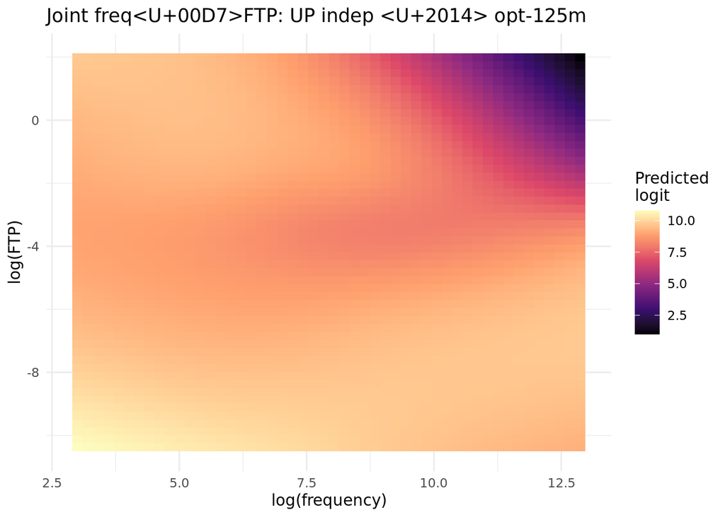

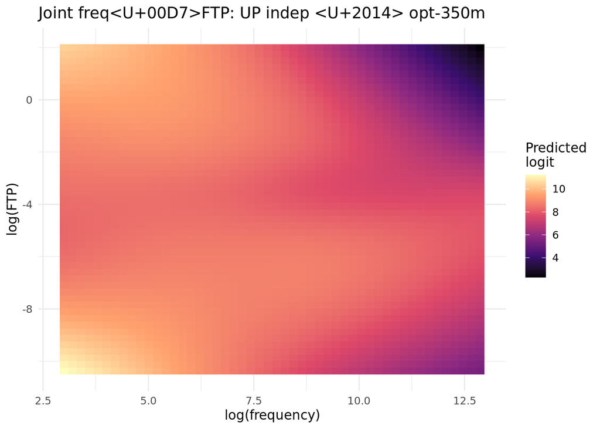

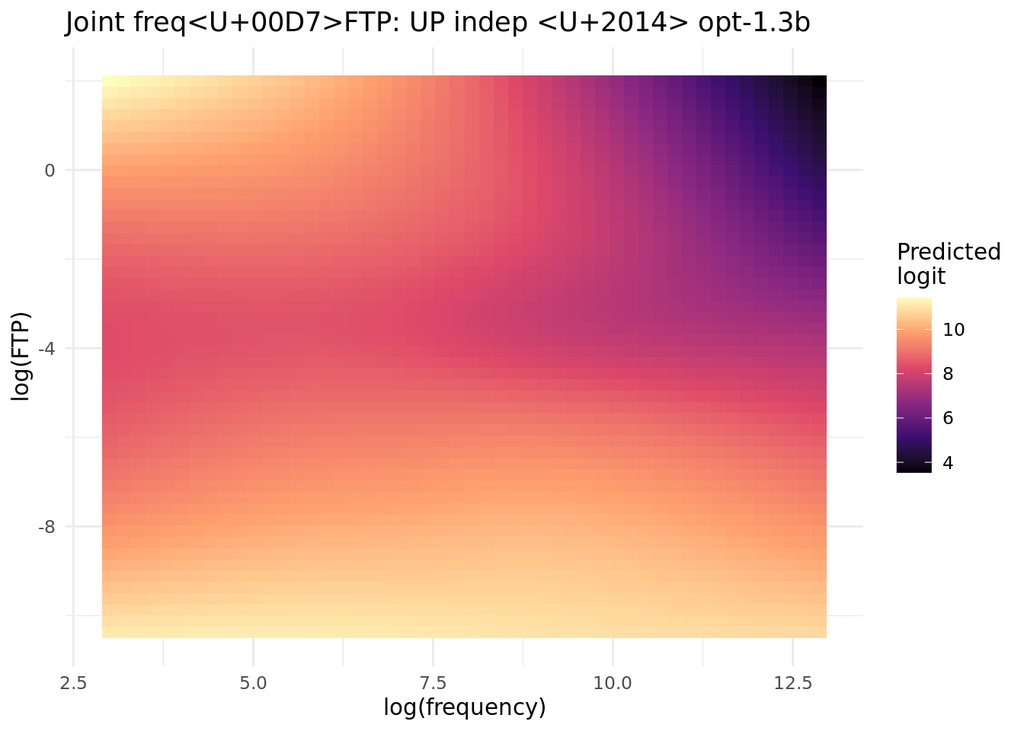

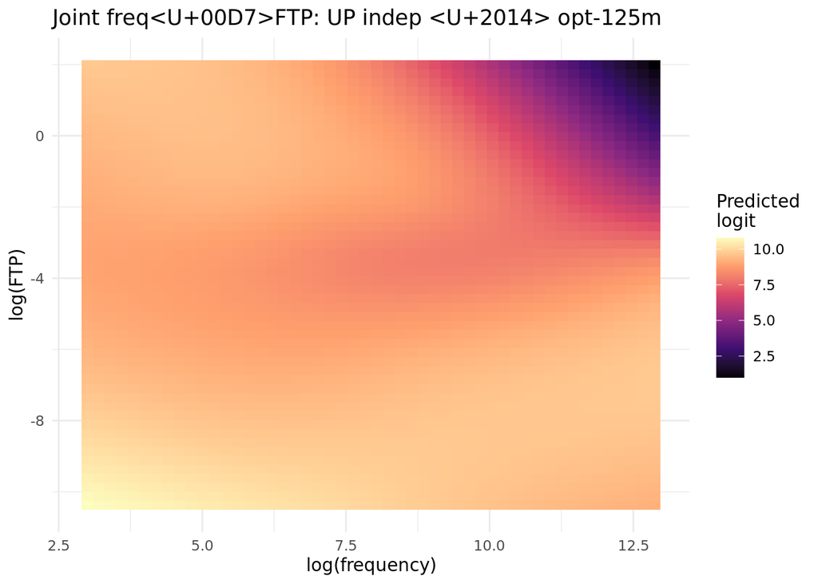

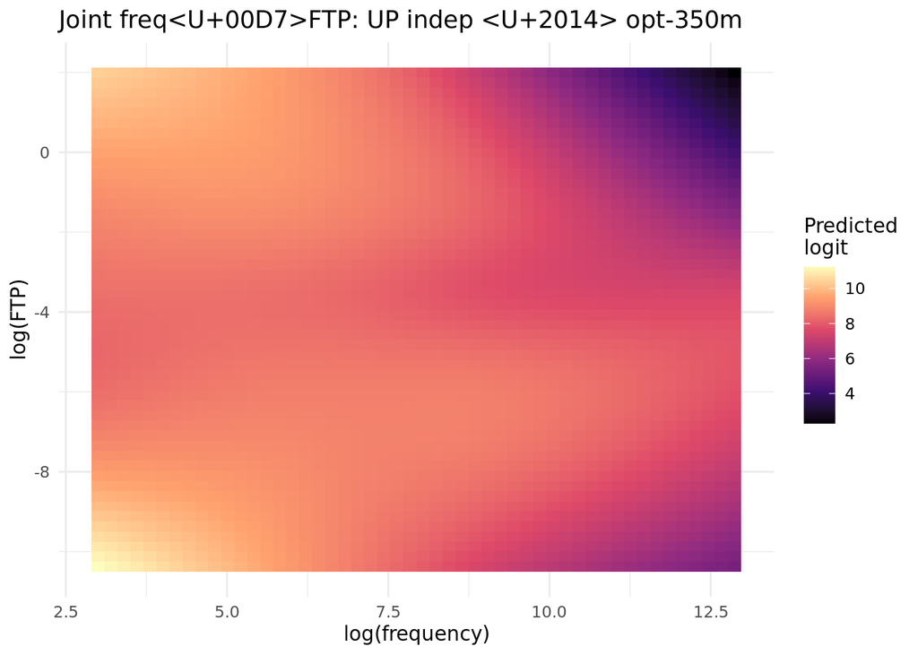

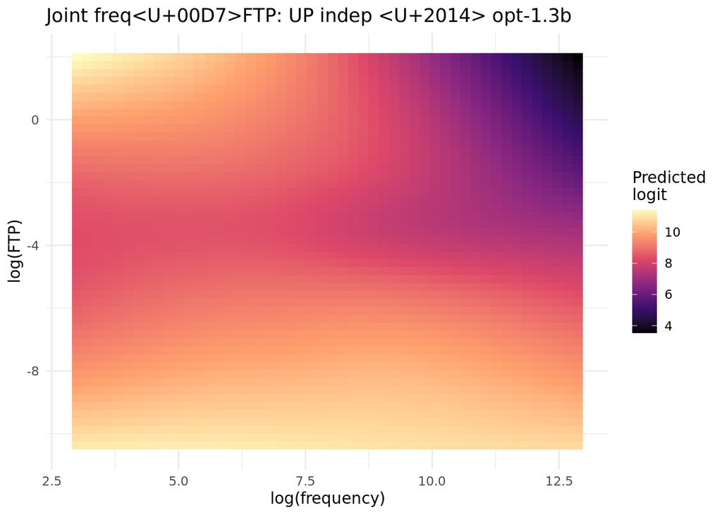

```r
lapply(BLM_TAGS, function(tag) {
  print(plot_joint_surface(blm_bam_joint_indep_final_models[[tag]],
                            blm_indep_final_ftp %>% filter(model == tag),
                            paste0("Joint freq×FTP: UP indep — ", tag))$heatmap)
})
```

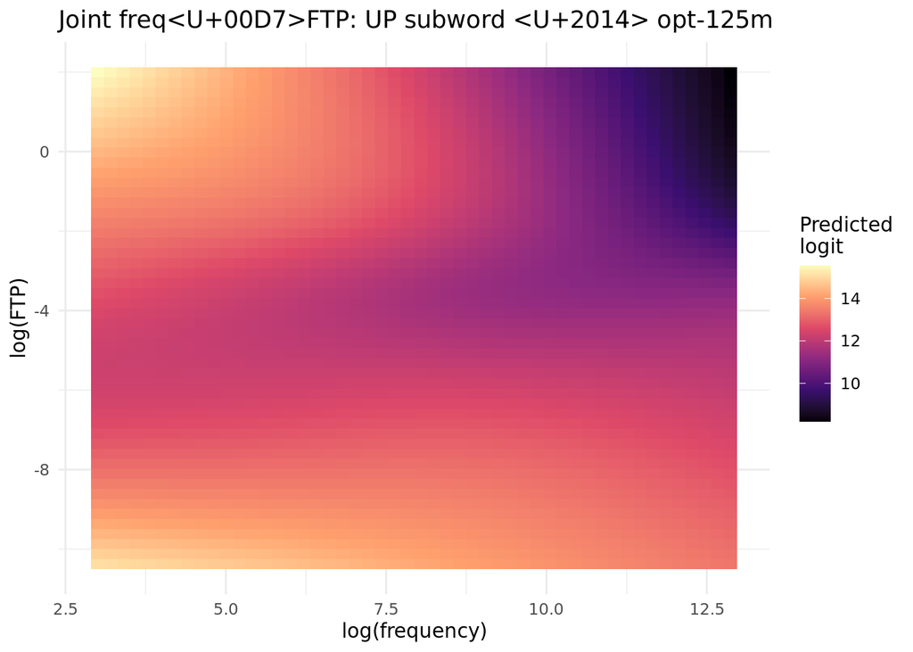

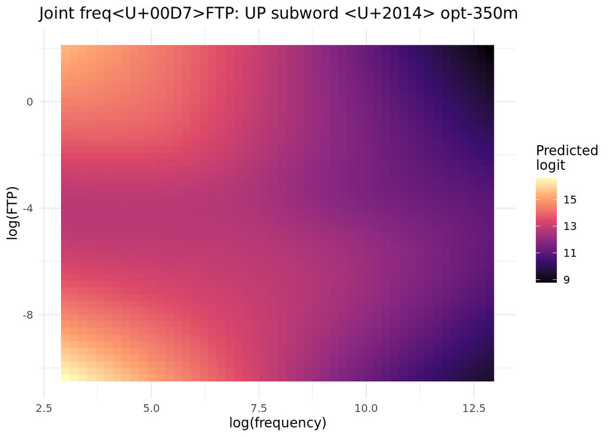

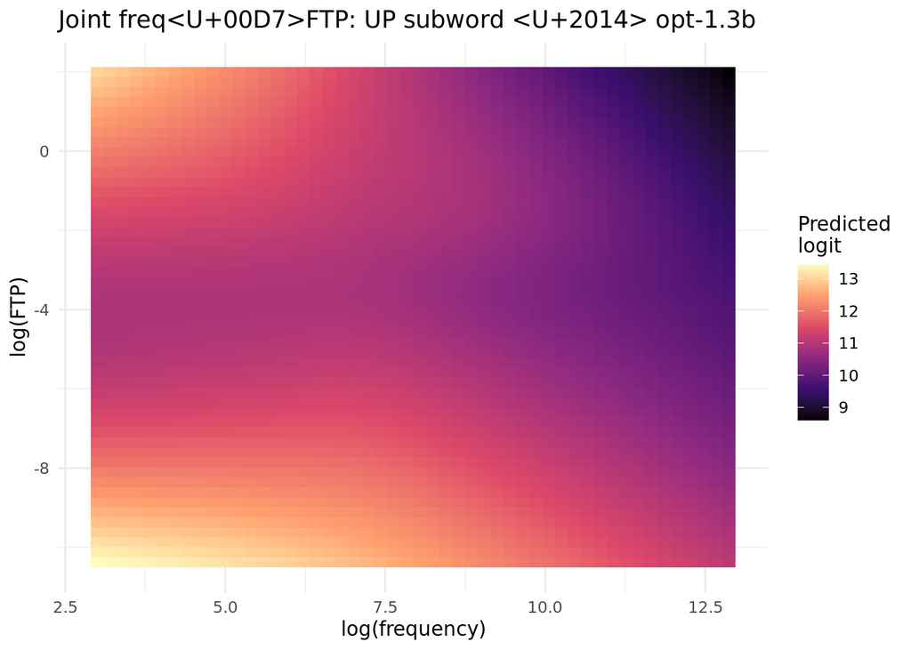

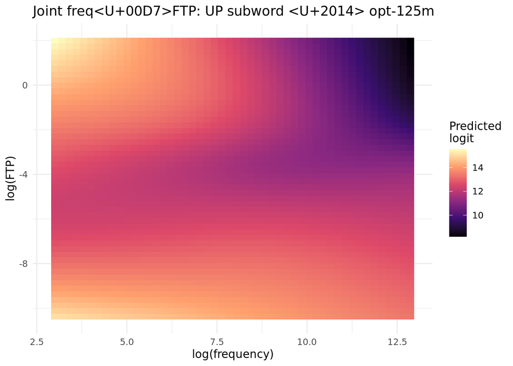

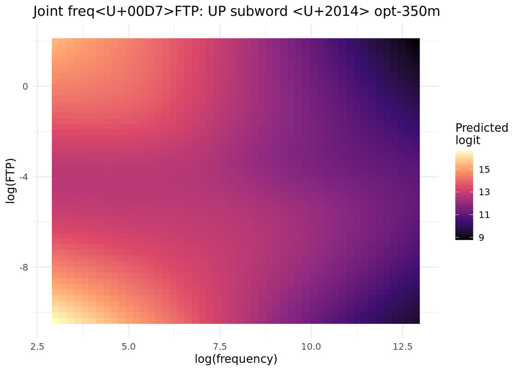

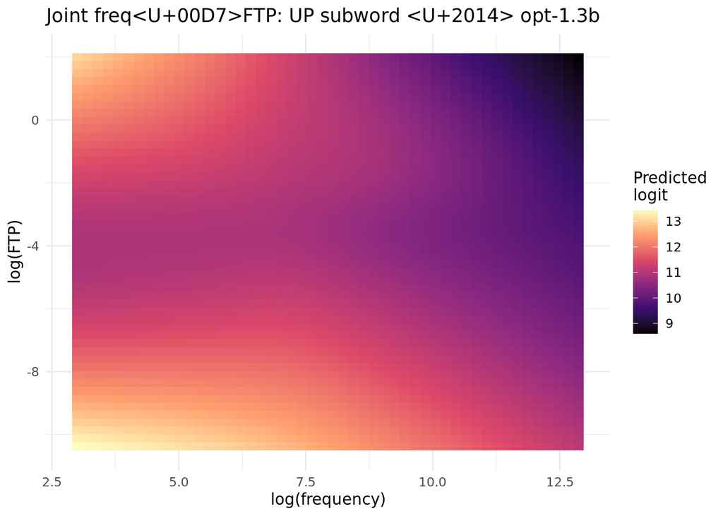

```r
lapply(BLM_TAGS, function(tag) {
  print(plot_joint_surface(blm_bam_joint_sub_final_models[[tag]],
                            blm_sub_final_ftp %>% filter(model == tag),
                            paste0("Joint freq×FTP: UP subword — ", tag))$heatmap)
})
```

### Freq and FTP across layers — per model (additive bam)

```r
set.seed(964)
blm_freq_ftp_layer_indep_models = lapply(setNames(BLM_TAGS, BLM_TAGS), function(tag) {
  blm_cache_bam(paste0("model_freq_ftp_layer_indep_", blm_slug(tag)), function() {
    bam(logit ~ te(log_freq, layer) + te(log_ftp, layer) + s(verb_up, bs = 're'),
        data = blm_indep_ftp %>% filter(model == tag), method = 'fREML', discrete = TRUE)
  })
})
blm_freq_ftp_layer_sub_models = lapply(setNames(BLM_TAGS, BLM_TAGS), function(tag) {
  blm_cache_bam(paste0("model_freq_ftp_layer_sub_", blm_slug(tag)), function() {
    bam(logit ~ te(log_freq, layer) + te(log_ftp, layer) + s(verb_up, bs = 're'),
        data = blm_subword_ftp %>% filter(model == tag), method = 'fREML', discrete = TRUE)
  })
})
lapply(blm_freq_ftp_layer_indep_models, summary)
```

```
## $`opt-125m`
##
## Family: gaussian
## Link function: identity
##
## Formula:
## logit ~ te(log_freq, layer) + te(log_ftp, layer) + s(verb_up,
##     bs = "re")
##
## Parametric coefficients:
##             Estimate Std. Error t value Pr(>|t|)
## (Intercept)  9.97115    0.02486   401.1   <2e-16 ***
## ---
## Signif. codes:  0 '***' 0.001 '**' 0.01 '*' 0.05 '.' 0.1 ' ' 1
##
## Approximate significance of smooth terms:
##                        edf  Ref.df      F p-value
## te(log_freq,layer)   16.13   17.66  81.84  <2e-16 ***
## te(log_ftp,layer)    21.28   21.61 145.59  <2e-16 ***
## s(verb_up)         1019.55 1036.00 136.40  <2e-16 ***
## ---
## Signif. codes:  0 '***' 0.001 '**' 0.01 '*' 0.05 '.' 0.1 ' ' 1
##
## R-sq.(adj) =  0.119   Deviance explained = 12.3%
## fREML = 4.1691e+05  Scale est. = 1.6918    n = 246492
##
## $`opt-350m`
##
## Family: gaussian
## Link function: identity
##
## Formula:
## logit ~ te(log_freq, layer) + te(log_ftp, layer) + s(verb_up,
##     bs = "re")
##
## Parametric coefficients:
##             Estimate Std. Error t value Pr(>|t|)
## (Intercept) 13.28716    0.01837   723.2   <2e-16 ***
## ---
## Signif. codes:  0 '***' 0.001 '**' 0.01 '*' 0.05 '.' 0.1 ' ' 1
```

[output cut: 22 more lines]

```
##             Estimate Std. Error t value Pr(>|t|)
## (Intercept) 11.84382    0.04084     290   <2e-16 ***
## ---
## Signif. codes:  0 '***' 0.001 '**' 0.01 '*' 0.05 '.' 0.1 ' ' 1
##
## Approximate significance of smooth terms:
##                        edf  Ref.df     F p-value
## te(log_freq,layer)   17.82   18.83 141.6  <2e-16 ***
## te(log_ftp,layer)    21.22   21.48 168.7  <2e-16 ***
## s(verb_up)         1025.19 1036.00 260.3  <2e-16 ***
## ---
## Signif. codes:  0 '***' 0.001 '**' 0.01 '*' 0.05 '.' 0.1 ' ' 1
##
## R-sq.(adj) =  0.455   Deviance explained = 45.7%
## fREML = 1.1215e+06  Scale est. = 5.4811    n = 492984
```

```r
lapply(blm_freq_ftp_layer_sub_models, summary)
```

```
## $`opt-125m`
##
## Family: gaussian
## Link function: identity
##
## Formula:
## logit ~ te(log_freq, layer) + te(log_ftp, layer) + s(verb_up,
##     bs = "re")
##
## Parametric coefficients:
##             Estimate Std. Error t value Pr(>|t|)
## (Intercept) 12.80600    0.05172   247.6   <2e-16 ***
## ---
## Signif. codes:  0 '***' 0.001 '**' 0.01 '*' 0.05 '.' 0.1 ' ' 1
##
## Approximate significance of smooth terms:
##                        edf  Ref.df      F p-value
## te(log_freq,layer)   15.95   17.79 137.79  <2e-16 ***
## te(log_ftp,layer)    20.65   21.21 157.02  <2e-16 ***
## s(verb_up)         1020.29 1036.00  91.49  <2e-16 ***
## ---
## Signif. codes:  0 '***' 0.001 '**' 0.01 '*' 0.05 '.' 0.1 ' ' 1
##
## R-sq.(adj) =  -0.0148   Deviance explained = -1.04%
## fREML = 6.0216e+05  Scale est. = 7.6072    n = 246492
##
## $`opt-350m`
##
## Family: gaussian
## Link function: identity
##
## Formula:
## logit ~ te(log_freq, layer) + te(log_ftp, layer) + s(verb_up,
##     bs = "re")
##
## Parametric coefficients:
##             Estimate Std. Error t value Pr(>|t|)
## (Intercept) 14.95896    0.02477   603.8   <2e-16 ***
## ---
## Signif. codes:  0 '***' 0.001 '**' 0.01 '*' 0.05 '.' 0.1 ' ' 1
```

[output cut: 22 more lines]

```
##             Estimate Std. Error t value Pr(>|t|)
## (Intercept) 13.65677    0.04643   294.1   <2e-16 ***
## ---
## Signif. codes:  0 '***' 0.001 '**' 0.01 '*' 0.05 '.' 0.1 ' ' 1
##
## Approximate significance of smooth terms:
##                        edf  Ref.df     F p-value
## te(log_freq,layer)   20.38   21.29 106.5  <2e-16 ***
## te(log_ftp,layer)    17.47   18.25  53.2  <2e-16 ***
## s(verb_up)         1024.90 1036.00 436.9  <2e-16 ***
## ---
## Signif. codes:  0 '***' 0.001 '**' 0.01 '*' 0.05 '.' 0.1 ' ' 1
##
## R-sq.(adj) =  0.385   Deviance explained = 38.6%
## fREML = 1.2197e+06  Scale est. = 8.167     n = 492984
```

# Whisper-small Analysis

Whisper embeddings are extracted via a single forward pass per utterance:

- **Encoder**: the hidden states at a given layer are mean-pooled over the audio frames spanning the “up” word’s time window (WhisperX word-level timestamps, 20 ms per encoder output frame). The resulting vector is the “up” embedding.
- **Decoder**: hidden states are extracted at the exact token position of “up” using teacher-forced decoding (the gold transcript is fed as decoder input).

A separate logistic regression classifier is trained **at each layer independently** on standalone “up” (positive) vs. random other-word (negative) embeddings. The classifier trained at layer *L* is then applied to V+up test embeddings extracted from that same layer *L*. No classifier trained on one layer is ever applied to another layer’s embeddings.

## Setup

```r
WH_COMPONENTS = c("encoder", "decoder")
```

## Effect of frequency at the final layer — per component (brms)

```r
wh_freq_final_models = lapply(setNames(WH_COMPONENTS, WH_COMPONENTS), function(comp) {
  brm(
    formula = logit ~ log_freq + (1 | verb_up),
    data    = whisper_final %>% filter(component == comp),
    prior   = priors,
    iter = 6000, warmup = 3000, chains = 4, cores = 4, seed = 964,
    file    = wh_brms_path(paste0("model_freq_final_", comp))
  )
})
lapply(wh_freq_final_models, summary)
```

```
## $encoder
##  Family: gaussian
##   Links: mu = identity
## Formula: logit ~ log_freq + (1 | verb_up)
##    Data: whisper_final %>% filter(component == comp) (Number of observations: 20308)
##   Draws: 4 chains, each with iter = 6000; warmup = 3000; thin = 1;
##          total post-warmup draws = 12000
##
## Multilevel Hyperparameters:
## ~verb_up (Number of levels: 1397)
##               Estimate Est.Error l-95% CI u-95% CI Rhat Bulk_ESS Tail_ESS
## sd(Intercept)     0.76      0.03     0.71     0.82 1.00     4406     6689
##
## Regression Coefficients:
##           Estimate Est.Error l-95% CI u-95% CI Rhat Bulk_ESS Tail_ESS
## Intercept     8.88      0.11     8.66     9.11 1.00     6200     7447
## log_freq      0.05      0.02     0.01     0.08 1.00     5764     7362
##
## Further Distributional Parameters:
##       Estimate Est.Error l-95% CI u-95% CI Rhat Bulk_ESS Tail_ESS
## sigma     2.61      0.01     2.58     2.64 1.00    13816     8872
##
## Draws were sampled using sampling(NUTS). For each parameter, Bulk_ESS
## and Tail_ESS are effective sample size measures, and Rhat is the potential
## scale reduction factor on split chains (at convergence, Rhat = 1).
##
## $decoder
##  Family: gaussian
##   Links: mu = identity
## Formula: logit ~ log_freq + (1 | verb_up)
##    Data: whisper_final %>% filter(component == comp) (Number of observations: 20308)
##   Draws: 4 chains, each with iter = 6000; warmup = 3000; thin = 1;
##          total post-warmup draws = 12000
##
## Multilevel Hyperparameters:
## ~verb_up (Number of levels: 1397)
##               Estimate Est.Error l-95% CI u-95% CI Rhat Bulk_ESS Tail_ESS
## sd(Intercept)     1.65      0.04     1.56     1.74 1.00     3079     4916
##
## Regression Coefficients:
##           Estimate Est.Error l-95% CI u-95% CI Rhat Bulk_ESS Tail_ESS
## Intercept     9.61      0.21     9.21    10.02 1.00     2800     5054
## log_freq     -0.16      0.03    -0.22    -0.10 1.00     2475     4613
##
## Further Distributional Parameters:
##       Estimate Est.Error l-95% CI u-95% CI Rhat Bulk_ESS Tail_ESS
## sigma     3.65      0.02     3.61     3.69 1.00    12882     8764
##
## Draws were sampled using sampling(NUTS). For each parameter, Bulk_ESS
## and Tail_ESS are effective sample size measures, and Rhat is the potential
## scale reduction factor on split chains (at convergence, Rhat = 1).
```

## Effect of frequency at the first layer — per component (brms)

```r
wh_freq_first_models = lapply(setNames(WH_COMPONENTS, WH_COMPONENTS), function(comp) {
  brm(
    formula = logit ~ log_freq + (1 | verb_up),
    data    = whisper_first %>% filter(component == comp),
    prior   = priors,
    iter = 6000, warmup = 3000, chains = 4, cores = 4, seed = 964,
    file    = wh_brms_path(paste0("model_freq_first_", comp))
  )
})
lapply(wh_freq_first_models, summary)
```

```
## $encoder
##  Family: gaussian
##   Links: mu = identity
## Formula: logit ~ log_freq + (1 | verb_up)
##    Data: whisper_first %>% filter(component == comp) (Number of observations: 20308)
##   Draws: 4 chains, each with iter = 6000; warmup = 3000; thin = 1;
##          total post-warmup draws = 12000
##
## Multilevel Hyperparameters:
## ~verb_up (Number of levels: 1397)
##               Estimate Est.Error l-95% CI u-95% CI Rhat Bulk_ESS Tail_ESS
## sd(Intercept)     1.44      0.06     1.31     1.56 1.00     4420     6968
##
## Regression Coefficients:
##           Estimate Est.Error l-95% CI u-95% CI Rhat Bulk_ESS Tail_ESS
## Intercept    13.07      0.24    12.59    13.55 1.00     6789     7858
## log_freq     -0.09      0.03    -0.16    -0.02 1.00     6452     7584
##
## Further Distributional Parameters:
##       Estimate Est.Error l-95% CI u-95% CI Rhat Bulk_ESS Tail_ESS
## sigma     6.12      0.03     6.06     6.18 1.00    13107     9236
##
## Draws were sampled using sampling(NUTS). For each parameter, Bulk_ESS
## and Tail_ESS are effective sample size measures, and Rhat is the potential
## scale reduction factor on split chains (at convergence, Rhat = 1).
##
## $decoder
##  Family: gaussian
##   Links: mu = identity
## Formula: logit ~ log_freq + (1 | verb_up)
##    Data: whisper_first %>% filter(component == comp) (Number of observations: 20308)
##   Draws: 4 chains, each with iter = 6000; warmup = 3000; thin = 1;
##          total post-warmup draws = 12000
##
## Multilevel Hyperparameters:
## ~verb_up (Number of levels: 1397)
##               Estimate Est.Error l-95% CI u-95% CI Rhat Bulk_ESS Tail_ESS
## sd(Intercept)     0.50      0.01     0.47     0.52 1.00     3068     5071
##
## Regression Coefficients:
##           Estimate Est.Error l-95% CI u-95% CI Rhat Bulk_ESS Tail_ESS
## Intercept     9.15      0.06     9.03     9.27 1.00     3209     5371
## log_freq      0.01      0.01    -0.00     0.03 1.00     2921     4871
##
## Further Distributional Parameters:
##       Estimate Est.Error l-95% CI u-95% CI Rhat Bulk_ESS Tail_ESS
## sigma     1.09      0.01     1.08     1.10 1.00    12637     8930
##
## Draws were sampled using sampling(NUTS). For each parameter, Bulk_ESS
## and Tail_ESS are effective sample size measures, and Rhat is the potential
## scale reduction factor on split chains (at convergence, Rhat = 1).
```

## Effect of frequency at the final layer — per component (bam — non-linear)

```r
set.seed(964)
wh_bam_freq_final_models = lapply(setNames(WH_COMPONENTS, WH_COMPONENTS), function(comp) {
  wh_cache_bam(paste0("bam_freq_final_", comp), function() {
    bam(logit ~ s(log_freq) + s(verb_up, bs = 're'),
        data = whisper_final %>% filter(component == comp), method = 'fREML', discrete = TRUE)
  })
})
lapply(wh_bam_freq_final_models, summary)
```

```
## $encoder
##
## Family: gaussian
## Link function: identity
##
## Formula:
## logit ~ s(log_freq) + s(verb_up, bs = "re")
##
## Parametric coefficients:
##             Estimate Std. Error t value Pr(>|t|)
## (Intercept)  9.20926    0.02896     318   <2e-16 ***
## ---
## Signif. codes:  0 '***' 0.001 '**' 0.01 '*' 0.05 '.' 0.1 ' ' 1
##
## Approximate significance of smooth terms:
##                 edf   Ref.df     F p-value
## s(log_freq)   3.202    3.574 3.913  0.0105 *
## s(verb_up)  730.663 1395.000 1.235  <2e-16 ***
## ---
## Signif. codes:  0 '***' 0.001 '**' 0.01 '*' 0.05 '.' 0.1 ' ' 1
##
## R-sq.(adj) =  0.0793   Deviance explained = 11.3%
## fREML =  48843  Scale est. = 6.8081    n = 20308
##
## $decoder
##
## Family: gaussian
## Link function: identity
##
## Formula:
## logit ~ s(log_freq) + s(verb_up, bs = "re")
##
## Parametric coefficients:
##             Estimate Std. Error t value Pr(>|t|)
## (Intercept)  8.48935    0.05341   158.9   <2e-16 ***
## ---
## Signif. codes:  0 '***' 0.001 '**' 0.01 '*' 0.05 '.' 0.1 ' ' 1
##
## Approximate significance of smooth terms:
##                 edf   Ref.df      F p-value
## s(log_freq)   3.294    3.521 10.273  <2e-16 ***
## s(verb_up)  994.290 1395.000  2.965  <2e-16 ***
## ---
## Signif. codes:  0 '***' 0.001 '**' 0.01 '*' 0.05 '.' 0.1 ' ' 1
##
## R-sq.(adj) =  0.171   Deviance explained = 21.2%
## fREML =  56046  Scale est. = 13.335    n = 20308
```

## Effect of frequency across all layers — per component (mgcv)

```r
set.seed(964)
wh_freq_layer_models = lapply(setNames(WH_COMPONENTS, WH_COMPONENTS), function(comp) {
  wh_cache_bam(paste0("model_freq_layer_", comp), function() {
    bam(logit ~ te(log_freq, layer) + s(verb_up, bs = 're'),
        data = whisper_all %>% filter(component == comp), method = 'fREML', discrete = TRUE)
  })
})
lapply(wh_freq_layer_models, summary)
```

```
## $encoder
##
## Family: gaussian
## Link function: identity
##
## Formula:
## logit ~ te(log_freq, layer) + s(verb_up, bs = "re")
##
## Parametric coefficients:
##             Estimate Std. Error t value Pr(>|t|)
## (Intercept) 11.04821    0.03405   324.4   <2e-16 ***
## ---
## Signif. codes:  0 '***' 0.001 '**' 0.01 '*' 0.05 '.' 0.1 ' ' 1
##
## Approximate significance of smooth terms:
##                        edf  Ref.df      F p-value
## te(log_freq,layer)   12.09   13.87 555.24  <2e-16 ***
## s(verb_up)         1283.74 1395.00  14.42  <2e-16 ***
## ---
## Signif. codes:  0 '***' 0.001 '**' 0.01 '*' 0.05 '.' 0.1 ' ' 1
##
## R-sq.(adj) =  0.0959   Deviance explained = 10.1%
## fREML = 6.9642e+05  Scale est. = 17.499    n = 243696
##
## $decoder
##
## Family: gaussian
## Link function: identity
##
## Formula:
## logit ~ te(log_freq, layer) + s(verb_up, bs = "re")
##
## Parametric coefficients:
##             Estimate Std. Error t value Pr(>|t|)
## (Intercept)  9.01930    0.01962   459.8   <2e-16 ***
## ---
## Signif. codes:  0 '***' 0.001 '**' 0.01 '*' 0.05 '.' 0.1 ' ' 1
##
## Approximate significance of smooth terms:
##                        edf  Ref.df      F p-value
## te(log_freq,layer)   22.07   22.83 534.48  <2e-16 ***
## s(verb_up)         1312.81 1395.00  21.17  <2e-16 ***
## ---
## Signif. codes:  0 '***' 0.001 '**' 0.01 '*' 0.05 '.' 0.1 ' ' 1
##
## R-sq.(adj) =  0.146   Deviance explained = 15.1%
## fREML = 5.1695e+05  Scale est. = 4.0037    n = 243696
```

## Whisper frequency plots

[figure not shown]

```r
# Final layer brms — one panel per component
wrap_plots(lapply(WH_COMPONENTS, function(comp) {
  plot_final_layer(wh_freq_final_models[[comp]],
                   whisper_final %>% filter(component == comp),
                   paste0("Whisper: freq at final layer — ", comp))
}))
```

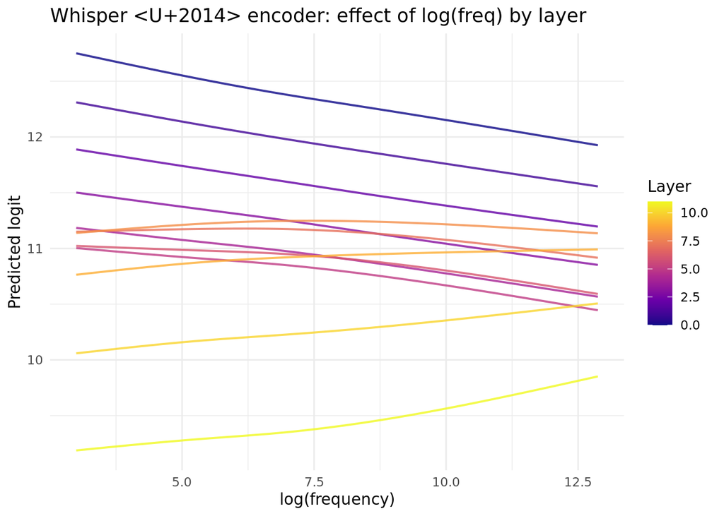

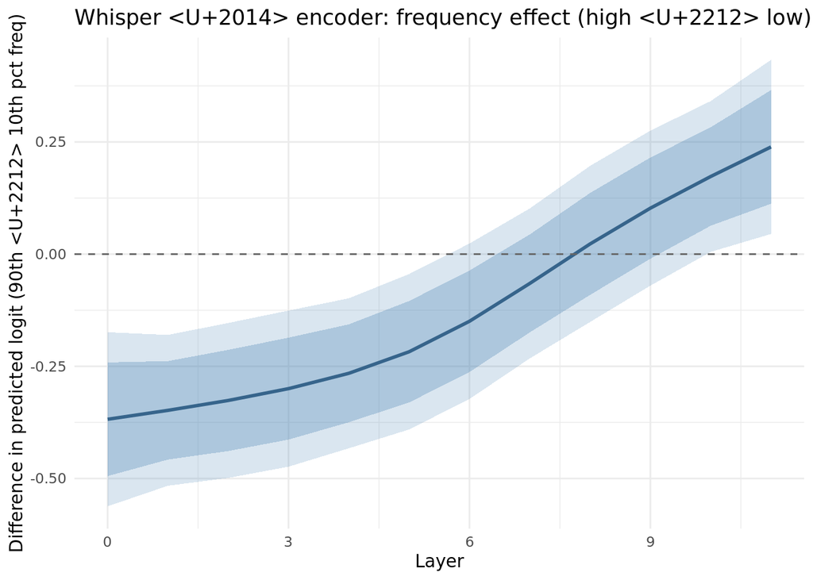

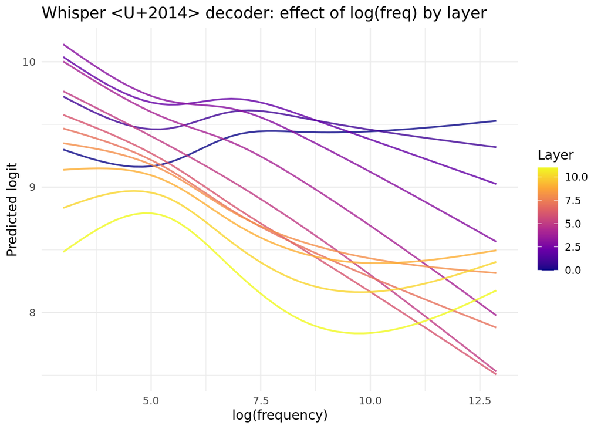

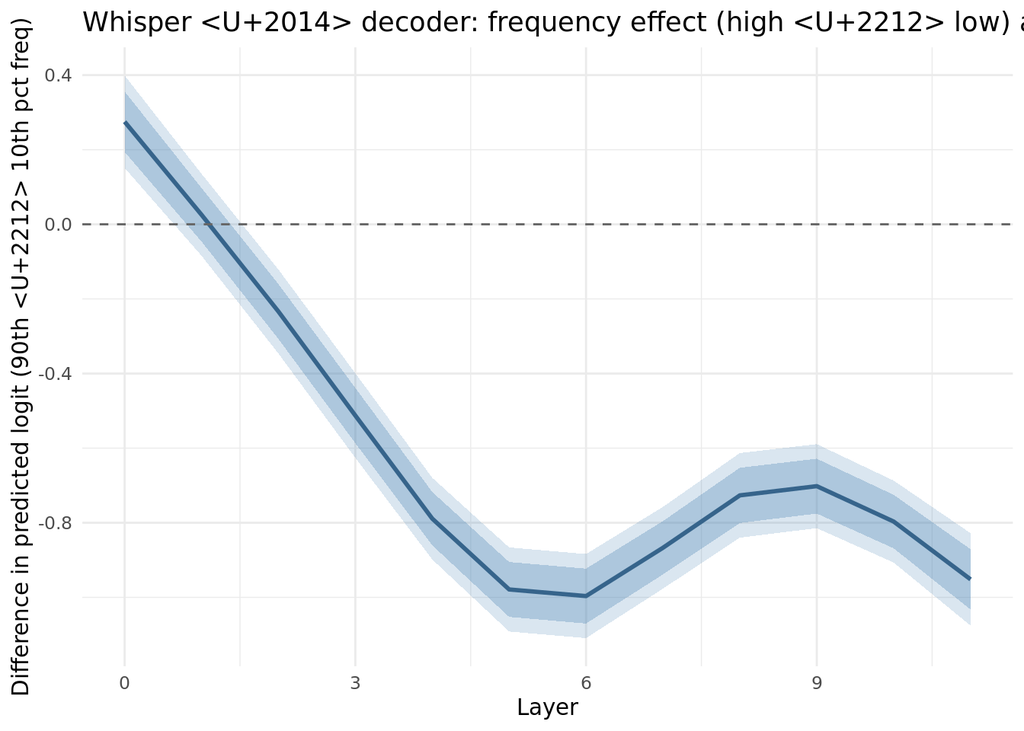

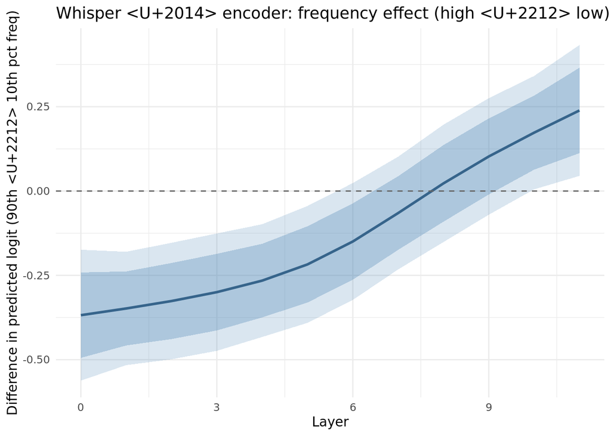

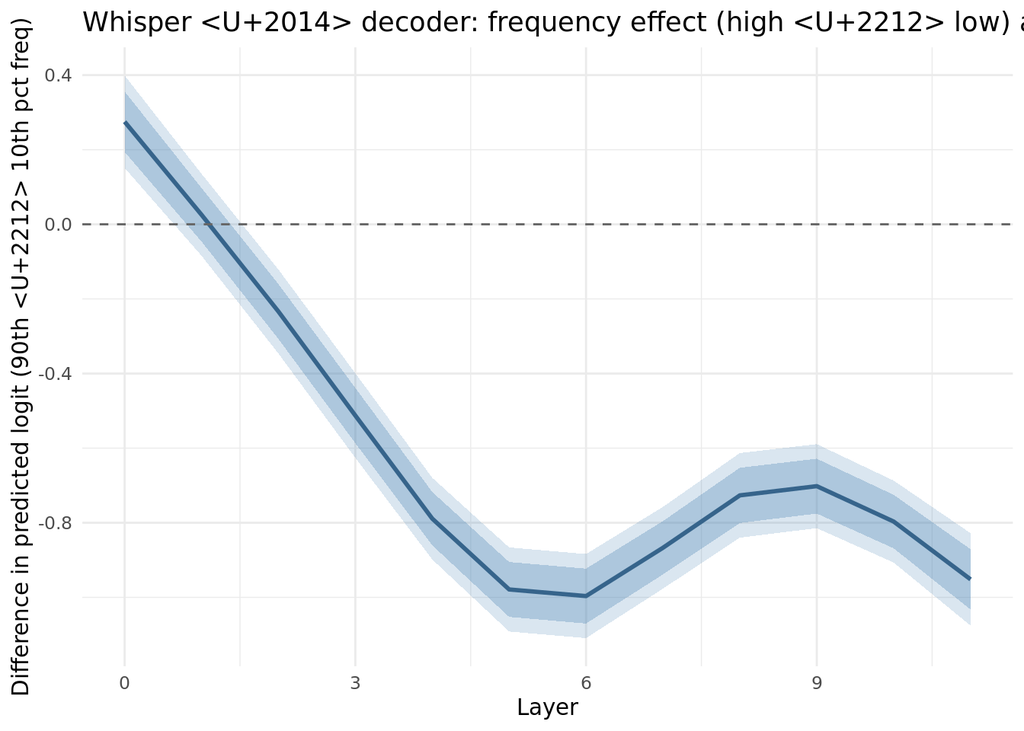

```r
# Frequency × layer spaghetti + diff plots per component
lapply(WH_COMPONENTS, function(comp) {
  plots = plot_freq_by_layer_mgcv(wh_freq_layer_models[[comp]],
                                   whisper_all %>% filter(component == comp),
                                   paste0("Whisper — ", comp),
                                   n_layers = WH_N_LAYERS)
  print(plots$spaghetti); print(plots$diff)
})
```

### Classifier validation accuracy across layers — encoder vs decoder

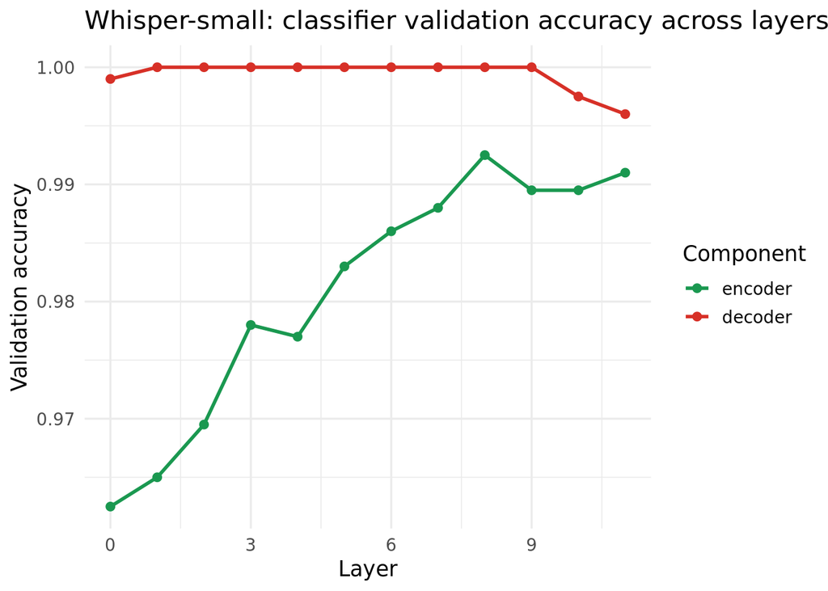

```r
read_layer_meta = function(path, component) {
  meta = jsonlite::fromJSON(path)
  meta$layers %>%
    mutate(component = component) %>%
    rename(val_oth_acc = val_other_acc) %>%
    select(layer, component, val_acc, val_up_acc, val_oth_acc, cv_mean)
}

meta_enc = read_layer_meta('../Data/whisper/encoder/layer_metadata.json', 'encoder')
meta_dec = read_layer_meta('../Data/whisper/decoder/layer_metadata.json', 'decoder')
wh_meta = bind_rows(meta_enc, meta_dec) %>%
  mutate(component = factor(component, levels = c("encoder", "decoder")))

wh_meta %>%
  ggplot(aes(x = layer, y = val_acc, color = component)) +
  geom_line(linewidth = 1) + geom_point(size = 2) +
  scale_color_manual(values = c("encoder" = "#1a9850", "decoder" = "#d73027")) +
  labs(title = "Whisper-small: classifier validation accuracy across layers",
       x = "Layer", y = "Validation accuracy", color = "Component") +
  theme_minimal(base_size = 13)
```

### Spearman correlation between log(frequency) and mean logit — across layers

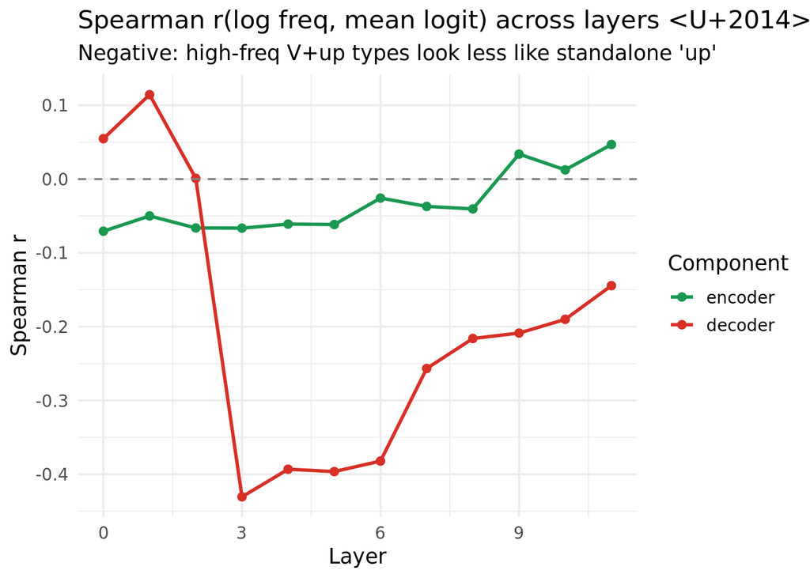

```r
wh_summary_by_layer = whisper_all %>%
  group_by(component, layer, verb_up, frequency) %>%
  summarise(mean_logit = mean(logit), .groups = "drop")

wh_cor_by_layer = wh_summary_by_layer %>%
  group_by(component, layer) %>%
  summarise(spearman_r = cor(log(frequency), mean_logit, method = "spearman"),
            .groups = "drop")

wh_cor_by_layer %>%
  ggplot(aes(x = layer, y = spearman_r, color = component)) +
  geom_line(linewidth = 1) + geom_point(size = 2) +
  geom_hline(yintercept = 0, linetype = "dashed", color = "gray50") +
  scale_color_manual(values = c("encoder" = "#1a9850", "decoder" = "#d73027")) +
  labs(title = "Spearman r(log freq, mean logit) across layers — encoder vs decoder",
       subtitle = "Negative: high-freq V+up types look less like standalone 'up'",
       x = "Layer", y = "Spearman r", color = "Component") +
  theme_minimal(base_size = 13)
```

### Most and least compositional V+up types — final layer

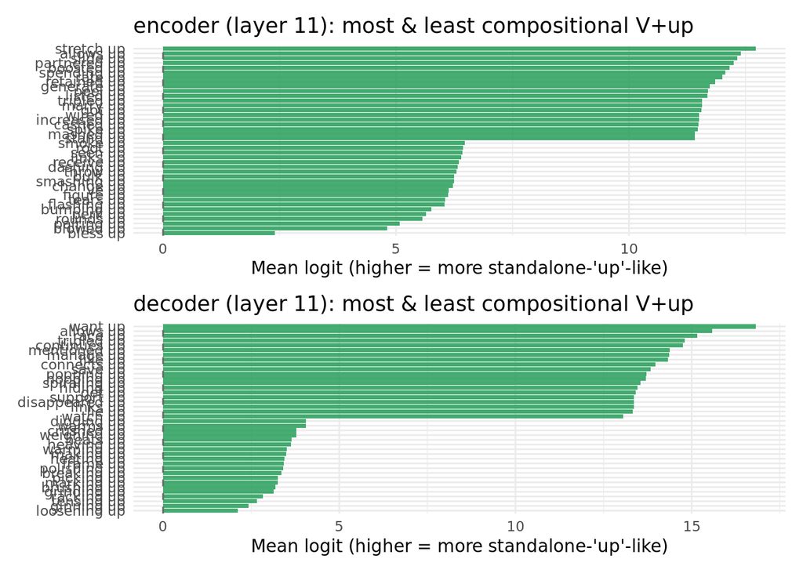

```r
plot_top_bottom = function(data, component_name, layer_num = 11) {
  d = data %>%
    filter(component == component_name, layer == layer_num) %>%
    group_by(verb_up, frequency) %>%
    summarise(mean_logit = mean(logit), .groups = "drop")
  n_show = 20
  bar_df = bind_rows(
    d %>% slice_max(mean_logit, n = n_show),
    d %>% slice_min(mean_logit, n = n_show)
  ) %>% distinct(verb_up, .keep_all = TRUE) %>% arrange(mean_logit)
  colors = ifelse(bar_df$mean_logit < 0, "#d73027", "#1a9850")
  bar_df %>%
    ggplot(aes(x = mean_logit, y = reorder(verb_up, mean_logit))) +
    geom_col(fill = colors, alpha = 0.8) +
    geom_vline(xintercept = 0, linetype = "dashed", color = "gray40") +
    labs(title = paste0(component_name, " (layer ", layer_num,
                        "): most & least compositional V+up"),
         x = "Mean logit (higher = more standalone-'up'-like)", y = NULL) +
    theme_minimal(base_size = 11)
}

plot_top_bottom(whisper_all, "encoder") /
plot_top_bottom(whisper_all, "decoder")
```

## Whisper — Predictability (FTP = P(up|V))

```r
whisper_final_ftp = whisper_final %>% filter(!is.na(log_ftp)) %>%
  group_by(component) %>%
  mutate(c_log_freq = c(scale(log_freq)), c_log_ftp = c(scale(log_ftp))) %>% ungroup()
whisper_first_ftp = whisper_first %>% filter(!is.na(log_ftp)) %>%
  group_by(component) %>%
  mutate(c_log_freq = c(scale(log_freq)), c_log_ftp = c(scale(log_ftp))) %>% ungroup()
whisper_ftp       = whisper_all   %>% filter(!is.na(log_ftp))
```

### FTP at the final layer — per component (brms)

```r
wh_ftp_final_models = lapply(setNames(WH_COMPONENTS, WH_COMPONENTS), function(comp) {
  brm(
    formula = logit ~ log_ftp + (1 | verb_up),
    data    = whisper_final_ftp %>% filter(component == comp),
    prior   = priors,
    iter = 6000, warmup = 3000, chains = 4, cores = 4, seed = 964,
    file    = wh_brms_path(paste0("model_ftp_final_", comp))
  )
})
lapply(wh_ftp_final_models, summary)
```

```
## $encoder
##  Family: gaussian
##   Links: mu = identity
## Formula: logit ~ log_ftp + (1 | verb_up)
##    Data: whisper_final_ftp %>% filter(component == comp) (Number of observations: 20308)
##   Draws: 4 chains, each with iter = 6000; warmup = 3000; thin = 1;
##          total post-warmup draws = 12000
##
## Multilevel Hyperparameters:
## ~verb_up (Number of levels: 1397)
##               Estimate Est.Error l-95% CI u-95% CI Rhat Bulk_ESS Tail_ESS
## sd(Intercept)     0.77      0.03     0.71     0.82 1.00     4032     5589
##
## Regression Coefficients:
##           Estimate Est.Error l-95% CI u-95% CI Rhat Bulk_ESS Tail_ESS
## Intercept     9.12      0.06     9.00     9.24 1.00     5034     7964
## log_ftp      -0.02      0.01    -0.05     0.01 1.00     5625     8431
##
## Further Distributional Parameters:
##       Estimate Est.Error l-95% CI u-95% CI Rhat Bulk_ESS Tail_ESS
## sigma     2.61      0.01     2.58     2.64 1.00    12049     7739
##
## Draws were sampled using sampling(NUTS). For each parameter, Bulk_ESS
## and Tail_ESS are effective sample size measures, and Rhat is the potential
## scale reduction factor on split chains (at convergence, Rhat = 1).
##
## $decoder
##  Family: gaussian
##   Links: mu = identity
## Formula: logit ~ log_ftp + (1 | verb_up)
##    Data: whisper_final_ftp %>% filter(component == comp) (Number of observations: 20308)
##   Draws: 4 chains, each with iter = 6000; warmup = 3000; thin = 1;
##          total post-warmup draws = 12000
##
## Multilevel Hyperparameters:
## ~verb_up (Number of levels: 1397)
##               Estimate Est.Error l-95% CI u-95% CI Rhat Bulk_ESS Tail_ESS
## sd(Intercept)     1.61      0.04     1.53     1.69 1.00     3161     5528
##
## Regression Coefficients:
##           Estimate Est.Error l-95% CI u-95% CI Rhat Bulk_ESS Tail_ESS
## Intercept     7.62      0.11     7.40     7.84 1.00     2771     4873
## log_ftp      -0.23      0.03    -0.28    -0.18 1.00     3037     4950
##
## Further Distributional Parameters:
##       Estimate Est.Error l-95% CI u-95% CI Rhat Bulk_ESS Tail_ESS
## sigma     3.65      0.02     3.61     3.69 1.00    12192     8160
##
## Draws were sampled using sampling(NUTS). For each parameter, Bulk_ESS
## and Tail_ESS are effective sample size measures, and Rhat is the potential
## scale reduction factor on split chains (at convergence, Rhat = 1).
```

### FTP at the first layer — per component (brms)

```r
wh_ftp_first_models = lapply(setNames(WH_COMPONENTS, WH_COMPONENTS), function(comp) {
  brm(
    formula = logit ~ log_ftp + (1 | verb_up),
    data    = whisper_first_ftp %>% filter(component == comp),
    prior   = priors,
    iter = 6000, warmup = 3000, chains = 4, cores = 4, seed = 964,
    file    = wh_brms_path(paste0("model_ftp_first_", comp))
  )
})
lapply(wh_ftp_first_models, summary)
```

```
## $encoder
##  Family: gaussian
##   Links: mu = identity
## Formula: logit ~ log_ftp + (1 | verb_up)
##    Data: whisper_first_ftp %>% filter(component == comp) (Number of observations: 20308)
##   Draws: 4 chains, each with iter = 6000; warmup = 3000; thin = 1;
##          total post-warmup draws = 12000
##
## Multilevel Hyperparameters:
## ~verb_up (Number of levels: 1397)
##               Estimate Est.Error l-95% CI u-95% CI Rhat Bulk_ESS Tail_ESS
## sd(Intercept)     1.43      0.06     1.31     1.55 1.00     4378     6360
##
## Regression Coefficients:
##           Estimate Est.Error l-95% CI u-95% CI Rhat Bulk_ESS Tail_ESS
## Intercept    12.90      0.13    12.65    13.15 1.00     7242     8501
## log_ftp       0.12      0.03     0.06     0.17 1.00     7382     9205
##
## Further Distributional Parameters:
##       Estimate Est.Error l-95% CI u-95% CI Rhat Bulk_ESS Tail_ESS
## sigma     6.12      0.03     6.06     6.18 1.00    12082     8233
##
## Draws were sampled using sampling(NUTS). For each parameter, Bulk_ESS
## and Tail_ESS are effective sample size measures, and Rhat is the potential
## scale reduction factor on split chains (at convergence, Rhat = 1).
##
## $decoder
##  Family: gaussian
##   Links: mu = identity
## Formula: logit ~ log_ftp + (1 | verb_up)
##    Data: whisper_first_ftp %>% filter(component == comp) (Number of observations: 20308)
##   Draws: 4 chains, each with iter = 6000; warmup = 3000; thin = 1;
##          total post-warmup draws = 12000
##
## Multilevel Hyperparameters:
## ~verb_up (Number of levels: 1397)
##               Estimate Est.Error l-95% CI u-95% CI Rhat Bulk_ESS Tail_ESS
## sd(Intercept)     0.50      0.01     0.47     0.52 1.00     3410     5565
##
## Regression Coefficients:
##           Estimate Est.Error l-95% CI u-95% CI Rhat Bulk_ESS Tail_ESS
## Intercept     9.15      0.03     9.08     9.22 1.00     3325     6009
## log_ftp      -0.02      0.01    -0.04    -0.01 1.00     3742     5835
##
## Further Distributional Parameters:
##       Estimate Est.Error l-95% CI u-95% CI Rhat Bulk_ESS Tail_ESS
## sigma     1.09      0.01     1.08     1.10 1.00    13926     8747
##
## Draws were sampled using sampling(NUTS). For each parameter, Bulk_ESS
## and Tail_ESS are effective sample size measures, and Rhat is the potential
## scale reduction factor on split chains (at convergence, Rhat = 1).
```

### FTP at the final layer — per component (bam — non-linear)

```r
set.seed(964)
wh_bam_ftp_final_models = lapply(setNames(WH_COMPONENTS, WH_COMPONENTS), function(comp) {
  wh_cache_bam(paste0("bam_ftp_final_", comp), function() {
    bam(logit ~ s(log_ftp) + s(verb_up, bs = 're'),
        data = whisper_final_ftp %>% filter(component == comp), method = 'fREML', discrete = TRUE)
  })
})
lapply(wh_bam_ftp_final_models, summary)
```

```
## $encoder
##
## Family: gaussian
## Link function: identity
##
## Formula:
## logit ~ s(log_ftp) + s(verb_up, bs = "re")
##
## Parametric coefficients:
##             Estimate Std. Error t value Pr(>|t|)
## (Intercept)  9.23931    0.03125   295.6   <2e-16 ***
## ---
## Signif. codes:  0 '***' 0.001 '**' 0.01 '*' 0.05 '.' 0.1 ' ' 1
##
## Approximate significance of smooth terms:
##                edf   Ref.df     F p-value
## s(log_ftp)   2.684    3.044 3.556  0.0133 *
## s(verb_up) 733.272 1395.000 1.244  <2e-16 ***
## ---
## Signif. codes:  0 '***' 0.001 '**' 0.01 '*' 0.05 '.' 0.1 ' ' 1
##
## R-sq.(adj) =  0.0794   Deviance explained = 11.3%
## fREML =  48844  Scale est. = 6.8074    n = 20308
##
## $decoder
##
## Family: gaussian
## Link function: identity
##
## Formula:
## logit ~ s(log_ftp) + s(verb_up, bs = "re")
##
## Parametric coefficients:
##             Estimate Std. Error t value Pr(>|t|)
## (Intercept)  8.63648    0.05627   153.5   <2e-16 ***
## ---
## Signif. codes:  0 '***' 0.001 '**' 0.01 '*' 0.05 '.' 0.1 ' ' 1
##
## Approximate significance of smooth terms:
##                edf   Ref.df      F p-value
## s(log_ftp)   3.429    3.715 28.502  <2e-16 ***
## s(verb_up) 976.493 1395.000  2.743  <2e-16 ***
## ---
## Signif. codes:  0 '***' 0.001 '**' 0.01 '*' 0.05 '.' 0.1 ' ' 1
##
## R-sq.(adj) =  0.171   Deviance explained = 21.1%
## fREML =  56013  Scale est. = 13.333    n = 20308
```

### FTP × layer — per component (mgcv)

```r
set.seed(964)
wh_ftp_layer_models = lapply(setNames(WH_COMPONENTS, WH_COMPONENTS), function(comp) {
  wh_cache_bam(paste0("model_ftp_layer_", comp), function() {
    bam(logit ~ te(log_ftp, layer) + s(verb_up, bs = 're'),
        data = whisper_ftp %>% filter(component == comp), method = 'fREML', discrete = TRUE)
  })
})
lapply(wh_ftp_layer_models, summary)
```

```
## $encoder
##
## Family: gaussian
## Link function: identity
##
## Formula:
## logit ~ te(log_ftp, layer) + s(verb_up, bs = "re")
##
## Parametric coefficients:
##             Estimate Std. Error t value Pr(>|t|)
## (Intercept) 11.05361    0.03522   313.8   <2e-16 ***
## ---
## Signif. codes:  0 '***' 0.001 '**' 0.01 '*' 0.05 '.' 0.1 ' ' 1
##
## Approximate significance of smooth terms:
##                       edf  Ref.df      F p-value
## te(log_ftp,layer)   16.64   18.99 405.47  <2e-16 ***
## s(verb_up)        1282.88 1395.00  13.22  <2e-16 ***
## ---
## Signif. codes:  0 '***' 0.001 '**' 0.01 '*' 0.05 '.' 0.1 ' ' 1
##
## R-sq.(adj) =  0.0958   Deviance explained = 10.1%
## fREML = 6.9642e+05  Scale est. = 17.499    n = 243696
##
## $decoder
##
## Family: gaussian
## Link function: identity
##
## Formula:
## logit ~ te(log_ftp, layer) + s(verb_up, bs = "re")
##
## Parametric coefficients:
##             Estimate Std. Error t value Pr(>|t|)
## (Intercept)   9.1371     0.0202   452.3   <2e-16 ***
## ---
## Signif. codes:  0 '***' 0.001 '**' 0.01 '*' 0.05 '.' 0.1 ' ' 1
##
## Approximate significance of smooth terms:
##                       edf  Ref.df      F p-value
## te(log_ftp,layer)   22.03   22.96 557.91  <2e-16 ***
## s(verb_up)        1308.41 1395.00  19.52  <2e-16 ***
## ---
## Signif. codes:  0 '***' 0.001 '**' 0.01 '*' 0.05 '.' 0.1 ' ' 1
##
## R-sq.(adj) =  0.148   Deviance explained = 15.3%
## fREML = 5.1668e+05  Scale est. = 3.996     n = 243696
```

### FTP plots — per component

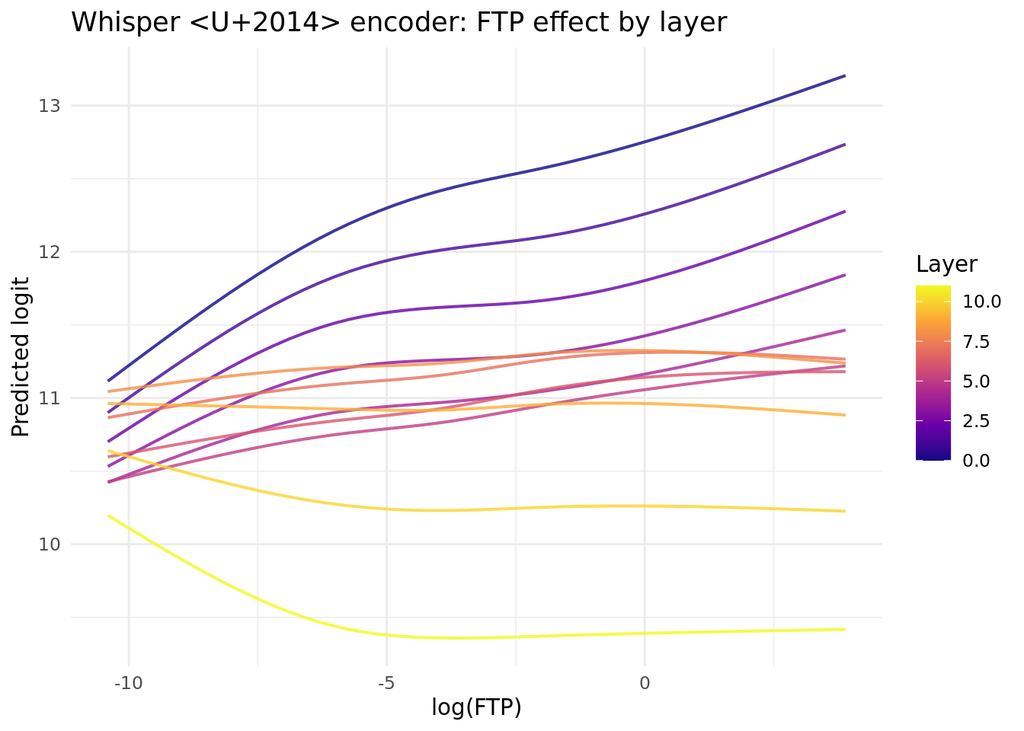

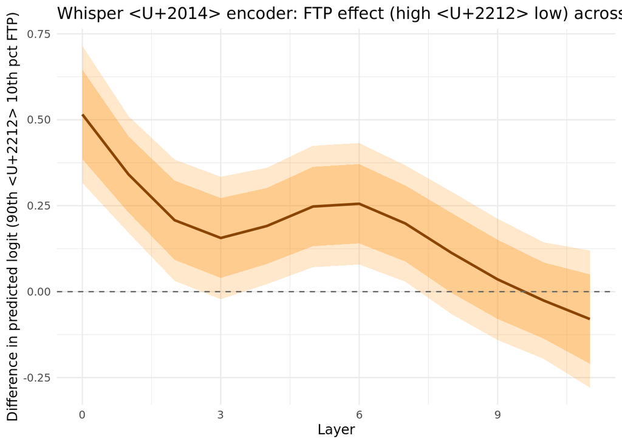

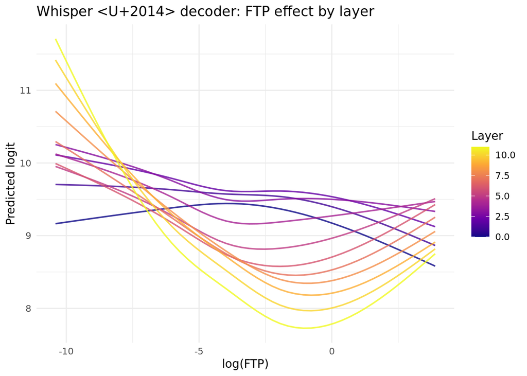

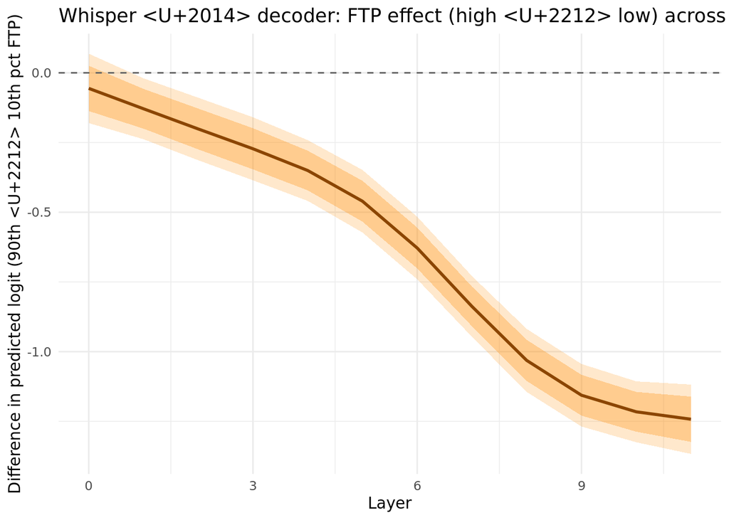

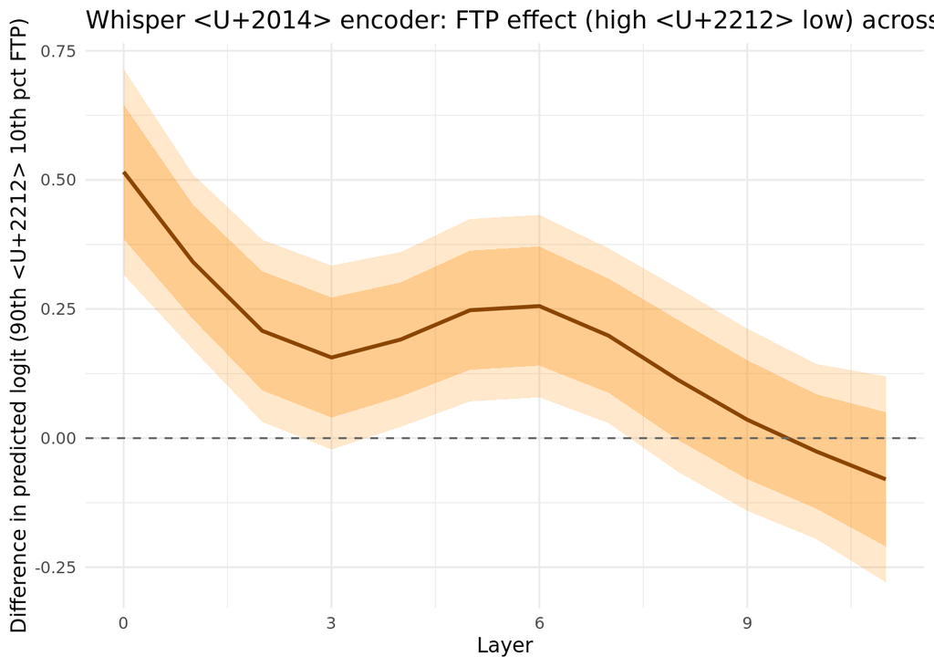

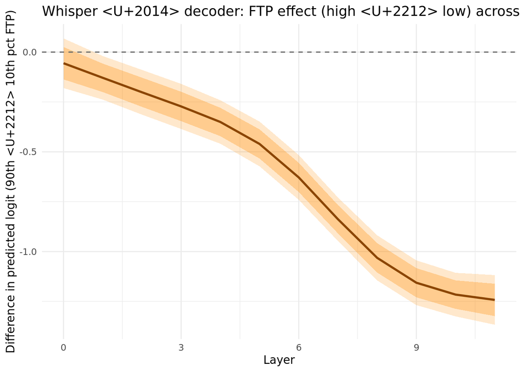

```r
lapply(WH_COMPONENTS, function(comp) {
  plots = plot_ftp_by_layer_mgcv(wh_ftp_layer_models[[comp]],
                                  whisper_ftp %>% filter(component == comp),
                                  paste0("Whisper — ", comp),
                                  n_layers = WH_N_LAYERS)
  print(plots$spaghetti); print(plots$diff)
})
```